# Medical Appointment Data Analytics

Aravind Diwakar : Anurag Panyala

November 17, 2017

## About the Project and Data

First Let’s talk a little bit about the data. The Data we have is a single CSV file that contains some information about patients and more importantly information about their medical appointment. The dataset comprises of 300k medical appointments of the public healthcare of the capital city of Espirito Santo State, Vitoria, Brazil and its 15 variables/characteristics of each. It also contains information about weather or not the patient showed up for their scheduled appointments.

## The R part

Let’s Start with some R analysis to see what factors seem to be influencing no-show for the appointments.

## Loading Libraries as needed

Here we are going to begin to load libraries as and when we need them.

```r
#install.packages('plyr')
#install.packages('dplyr')
#install.packages('ggplot2')
#install.packages('stringr')
#install.packages('scales')
#install.packages('tidyr')
#install.packages('lubridate')
#install.packages('gridExtra')
#install.packages('lattice')
#install.packages('caret')
#install.packages('grid')
#install.packages('rpart')
#install.packages('rpart.plot')
#install.packages('RColorBrewer')
library(plyr)
library(dplyr)
library(ggplot2)
library(stringr)
library(scales)
library(tidyr)
library(lubridate)
library(gridExtra)
library(grid)
library(lattice)
library(caret)
library(rpart)
library(rpart.plot)
library(RColorBrewer)
```

## Loading Data into Data frame

```r
#First we read the .csv file into a dataframe called rawdata
rawdata <- read.table("No-show-Issue-Comma-300k.csv", header=TRUE, sep=",", stringsAsFactors=TRUE)
#The raw data is then loaded into the 'newdata' dataframe, this is the dataframe which we'll be using
newdata <- rawdata
```

## Exploratory Data Analysis

```r
#Checking the structure of the dataframe
str(newdata)
```

```
## 'data.frame':    300000 obs. of  15 variables:
##  $ Age                    : int  19 24 4 5 38 5 46 4 20 51 ...
##  $ Gender                 : Factor w/ 2 levels "F","M": 2 1 1 2 2 1 1 1 1 1 ...
##  $ AppointmentRegistration: Factor w/ 295425 levels "2013-05-29T15:14:11Z",..: 152112 248200 23071 87268 274612 71585 225305 244749 125184 70354 ...
##  $ ApointmentData         : Factor w/ 534 levels "2014-01-02T00:00:00Z",..: 290 440 36 164 490 152 408 442 232 125 ...
##  $ DayOfTheWeek           : Factor w/ 7 levels "Friday","Monday",..: 7 7 6 5 6 6 6 1 6 6 ...
##  $ Status                 : Factor w/ 2 levels "NO","YES": 2 2 2 2 2 1 2 2 2 2 ...
##  $ Diabetes               : int  0 0 0 0 0 0 0 0 0 1 ...
##  $ Alcoolism              : int  0 0 0 0 0 0 0 0 0 0 ...
##  $ HiperTension           : int  0 0 0 0 0 0 0 0 0 1 ...
##  $ Handcap                : int  0 0 0 0 0 0 0 0 0 0 ...
##  $ Smokes                 : int  0 0 0 0 0 0 0 0 0 0 ...
##  $ Scholarship            : int  0 0 0 0 0 0 0 1 0 0 ...
##  $ Tuberculosis           : int  0 0 0 0 0 0 0 0 0 0 ...
##  $ Sms_Reminder           : int  0 0 0 1 1 1 1 1 0 1 ...
##  $ AwaitingTime           : int  -29 -1 -1 -15 -6 -35 -18 -14 -14 -4 ...
```

## Next we change the data types of various fields.

```r
#Changing date columns to date datatype
newdata$AppointmentRegistration <- ymd_hms(newdata$AppointmentRegistration)
newdata$ApointmentData <- ymd_hms(newdata$ApointmentData)

#Changing logical columns to logical datatype
newdata$Diabetes <- as.logical(newdata$Diabetes)
newdata$Alcoolism <- as.logical(newdata$Alcoolism)
newdata$HiperTension <- as.logical(newdata$HiperTension)
newdata$Smokes <- as.logical(newdata$Smokes)
newdata$Scholarship <- as.logical(newdata$Scholarship)
newdata$Tuberculosis <- as.logical(newdata$Tuberculosis)
newdata$Sms_Reminder <- as.logical(newdata$Sms_Reminder)
```

```r
#Re-checking the structre of the dataframe
str(newdata)
```

```
## 'data.frame':    300000 obs. of  15 variables:
##  $ Age                    : int  19 24 4 5 38 5 46 4 20 51 ...
##  $ Gender                 : Factor w/ 2 levels "F","M": 2 1 1 2 2 1 1 1 1 1 ...
##  $ AppointmentRegistration: POSIXct, format: "2014-12-16 14:46:25" "2015-08-18 07:01:26" ...
##  $ ApointmentData         : POSIXct, format: "2015-01-14" "2015-08-19" ...
##  $ DayOfTheWeek           : Factor w/ 7 levels "Friday","Monday",..: 7 7 6 5 6 6 6 1 6 6 ...
##  $ Status                 : Factor w/ 2 levels "NO","YES": 2 2 2 2 2 1 2 2 2 2 ...
##  $ Diabetes               : logi  FALSE FALSE FALSE FALSE FALSE FALSE ...
##  $ Alcoolism              : logi  FALSE FALSE FALSE FALSE FALSE FALSE ...
##  $ HiperTension           : logi  FALSE FALSE FALSE FALSE FALSE FALSE ...
##  $ Handcap                : int  0 0 0 0 0 0 0 0 0 0 ...
##  $ Smokes                 : logi  FALSE FALSE FALSE FALSE FALSE FALSE ...
##  $ Scholarship            : logi  FALSE FALSE FALSE FALSE FALSE FALSE ...
##  $ Tuberculosis           : logi  FALSE FALSE FALSE FALSE FALSE FALSE ...
##  $ Sms_Reminder           : logi  FALSE FALSE FALSE TRUE TRUE TRUE ...
##  $ AwaitingTime           : int  -29 -1 -1 -15 -6 -35 -18 -14 -14 -4 ...
```

Note: Handcap is the total number of disabilities a person presents, it is not binary.

```r
#Getting some summary stats
summary(newdata)
```

```
##       Age         Gender     AppointmentRegistration
##  Min.   : -2.00   F:200505   Min.   :2013-05-29 15:14:11
##  1st Qu.: 19.00   M: 99495   1st Qu.:2014-06-24 07:45:05
##  Median : 38.00              Median :2014-12-03 15:35:36
##  Mean   : 37.81              Mean   :2014-12-15 04:43:13
##  3rd Qu.: 56.00              3rd Qu.:2015-06-11 09:06:08
##  Max.   :113.00              Max.   :2015-12-29 12:08:58
##
##  ApointmentData                   DayOfTheWeek   Status
##  Min.   :2014-01-02 00:00:00   Friday   :52771   NO : 90731
##  1st Qu.:2014-07-04 00:00:00   Monday   :59298   YES:209269
##  Median :2014-12-16 00:00:00   Saturday : 1393
##  Mean   :2014-12-28 13:09:07   Sunday   :    6
##  3rd Qu.:2015-06-25 00:00:00   Thursday :60262
##  Max.   :2015-12-30 00:00:00   Tuesday  :62775
##                                Wednesday:63495
##   Diabetes       Alcoolism       HiperTension       Handcap
##  Mode :logical   Mode :logical   Mode :logical   Min.   :0.00000
##  FALSE:276610    FALSE:292497    FALSE:235233    1st Qu.:0.00000
##  TRUE :23390     TRUE :7503      TRUE :64767     Median :0.00000
##                                                  Mean   :0.02052
##                                                  3rd Qu.:0.00000
##                                                  Max.   :4.00000
##
##    Smokes        Scholarship     Tuberculosis    Sms_Reminder
##  Mode :logical   Mode :logical   Mode :logical   Mode :logical
##  FALSE:284289    FALSE:270931    FALSE:299865    FALSE:128547
##  TRUE :15711     TRUE :29069     TRUE :135       TRUE :171453
##
##
##
##
##   AwaitingTime
##  Min.   :-398.00
##  1st Qu.: -20.00
##  Median :  -8.00
##  Mean   : -13.84
##  3rd Qu.:  -4.00
##  Max.   :  -1.00
##
```

By looking at the above summary it can be inferred that the variable Age has some inconsistent values/outliers.

```r
summary(newdata$Age < 0)
```

```
##    Mode   FALSE    TRUE
## logical  299994       6
```

There appear to be only 6 inconsistent values/outliers for Age. This is a very small value of outliers when compared to the entire dataset, so we go ahead without making any changes to the Age variable.

## Plotting No-Show vs Show-Up

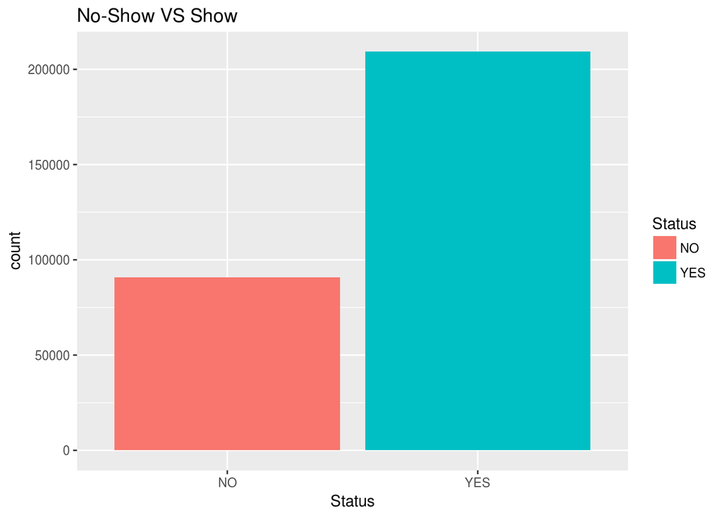

```r
gg_bar_status <- ggplot() + geom_bar(data = newdata, aes(x=Status, fill=Status)) + ggtitle("No-Show VS Show")
gg_bar_status
```

From the above graph it can be inferred that from the 300K medical appointements made, there were atleast 90K (30%) no-shows.

## Let’s Analyze to see if no-show depends on Age of the patient

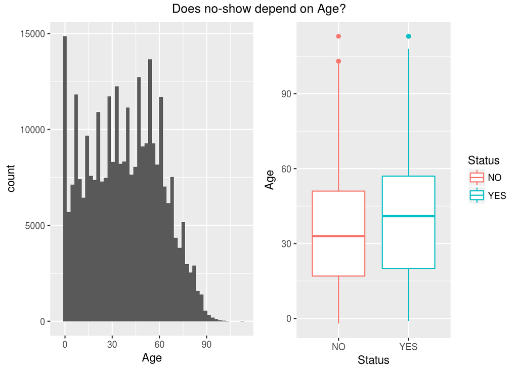

```r
gg_hist_age <- ggplot(newdata, aes(x=Age)) + geom_histogram(bins = 50)
gg_box_status_age <- ggplot(newdata, aes(x=Status, y=Age, col=Status)) + geom_boxplot()
grid.arrange(gg_hist_age, gg_box_status_age,ncol=2, top='Does no-show depend on Age?')
```

From the above graphs it can be inferred that younger patients are more likely to not show up for their mdeical appointement.

## Let’s Analyze to see if no-show depends on Gender of the patient

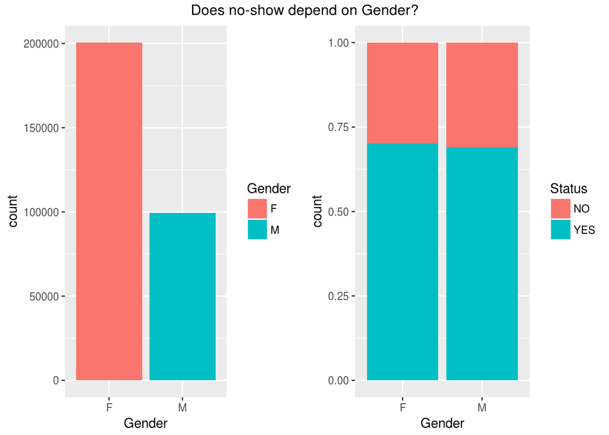

```r
gg_bar_gender <- ggplot(newdata, aes(x=Gender, fill=Gender)) + geom_bar()
gg_bar_gender_status <- ggplot(newdata, aes(x=Gender, fill=Status)) + geom_bar(position = "fill")
grid.arrange(gg_bar_gender, gg_bar_gender_status,ncol=2, top='Does no-show depend on Gender?')
```

By looking at the above bar plot on the left it can be inferred that, the number of female patients are almost double in number when compared to the male patients. By looking at the above bar plot on the right it can be inferred that, the patient’s gender doesn’t have much of an impact on showing up for an appointment.

## Counting appointments by Day Of The Week

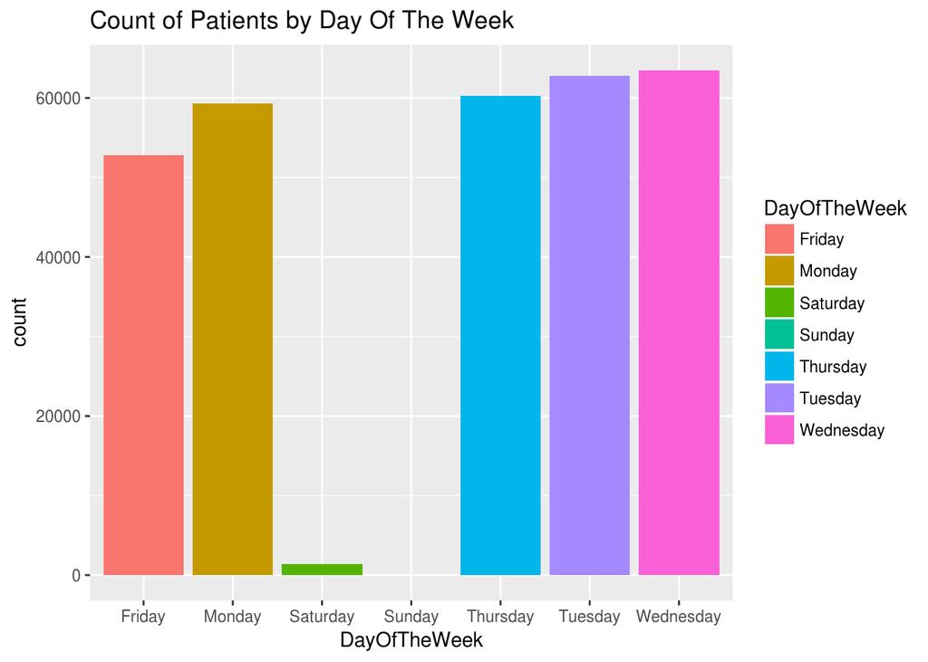

```r
gg_bar_dayoftheweek <- ggplot(newdata, aes(x=DayOfTheWeek, fill=DayOfTheWeek)) + geom_bar() + ggtitle("Count of Patients by Day Of The Week")
gg_bar_dayoftheweek
```

By looking at the above graph it can be inferred that, there are almost negligible number of appointments scheduled for the weekend. The doctor’s office might be closed on weekends and only emergencies might be scheduled for the weekends. Apart from the weekends, Friday seems to have the least number of appointments.

## Let’s Analyze to see if no-show depends on Day Of The Week of the appointment

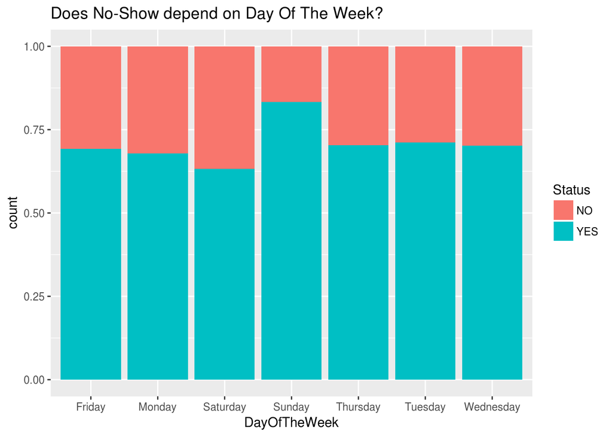

```r
gg_bar_dayoftheweek <- ggplot(newdata, aes(x=DayOfTheWeek, fill=Status)) + geom_bar(position = "fill") + ggtitle("Does No-Show depend on Day Of The Week?")
gg_bar_dayoftheweek
```

## Let’s Analyze to see if no-show depends on Sms Reminder being sent

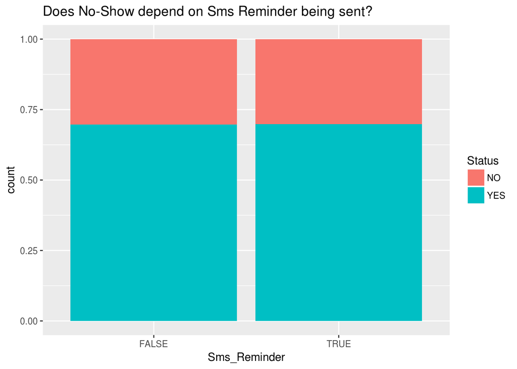

```r
gg_bar_smsreminder <- ggplot(newdata, aes(x=Sms_Reminder, fill=Status)) + geom_bar(position = "fill") + ggtitle("Does No-Show depend on Sms Reminder being sent?")
gg_bar_smsreminder
```

By looking at the above graph it can be inferred that, sending patients an sms reminding them of their appointment doesn’t have much of an impact on the no show rate.

## Let’s Analyze to see if no-show depends on a patient’s habits and medical conditions

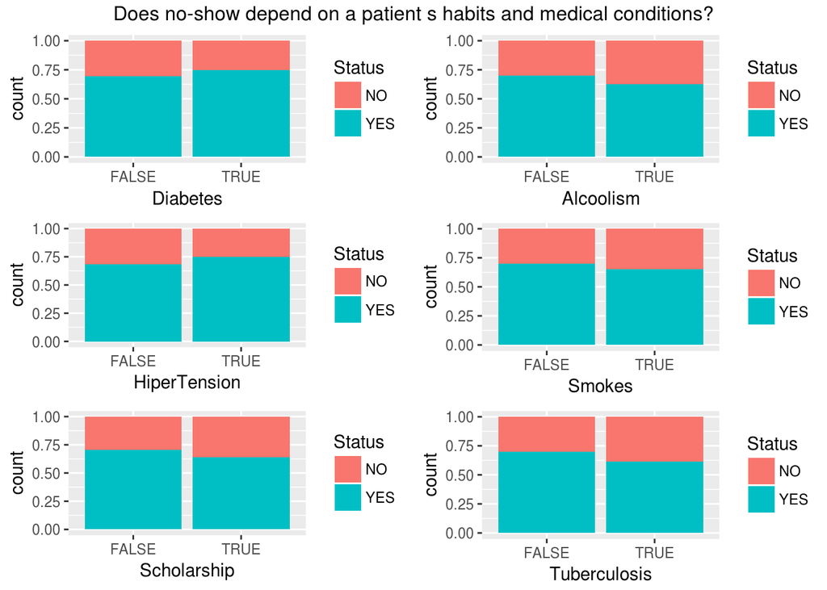

```r
gg_bar_diabetes <- ggplot(newdata, aes(x=Diabetes, fill=Status)) + geom_bar(position = "fill")
gg_bar_alcoolism <- ggplot(newdata, aes(x=Alcoolism, fill=Status)) + geom_bar(position = "fill")
gg_bar_hipertension <- ggplot(newdata, aes(x=HiperTension, fill=Status)) + geom_bar(position = "fill")
gg_bar_smokes <- ggplot(newdata, aes(x=Smokes, fill=Status)) + geom_bar(position = "fill")
gg_bar_scholarship <- ggplot(newdata, aes(x=Scholarship, fill=Status)) + geom_bar(position = "fill")
gg_bar_tuberculosis <- ggplot(newdata, aes(x=Tuberculosis, fill=Status)) + geom_bar(position = "fill")
grid.arrange(gg_bar_diabetes, gg_bar_alcoolism,gg_bar_hipertension, gg_bar_smokes, gg_bar_scholarship, gg_bar_tuberculosis, ncol=2, top='Does no-show depend on a patient s habits and medical conditions?')
```

The following inferences can be made with the help of the above bar plots:

Diabetes: Patients with diabetes have a higer rate of showing up for their medical appointment.

Alcoolism: Patients suffering from alcoholism have a much higher rate of not showing up.

HiperTension: Patients with hypertension appear to have a higher rate of showing up.

Smokes: Patients who are also smokers have a higher rate of not showing up for their appointments.

Scholarship: Scholarship/Bolsa Família (Portuguese pronunciation: [ˈbowsɐ fɐˈmiʎɐ], Family Allowance) is a social welfare program of the Brazilian government. It can be seen that patients who have inrolled in this welfare program are more likely to not show up for their mdeical appointment.

Tuberculosis: Patients suffering from tuberculosis are more likely to not show up for their medical appointment.

# Splitting data into Test and Training dataframes

```r
#Creating a 70/30 split for training and test data
set.seed(1592)
testrecs <- sample(nrow(newdata),0.3 * nrow(newdata))
newdata_test <- newdata[testrecs,]
newdata_train <- newdata[-testrecs,]
```

```r
# trainControl is used to control the computational nuances of the train function
fitControl <- trainControl(method = "cv",
                           number = 5,
                           #savePredictions="final",
                           summaryFunction = twoClassSummary,
                           classProbs = TRUE
                           )
```

## Model 1

We first start by building a model with all the variables in it

```r
train_glm1 <- train(Status~.,
                   newdata_train,
                   method = "glm",
                   metric = "ROC",
                   preProc = c("center", "scale"),
                   trControl = fitControl)

summary(train_glm1)
```

```
##
## Call:
## NULL
##
## Deviance Residuals:
##     Min       1Q   Median       3Q      Max
## -1.9436  -1.4040   0.7665   0.8756   2.2827
##
## Coefficients:
##                           Estimate Std. Error z value Pr(>|z|)
## (Intercept)              8.503e-01  4.826e-03 176.210  < 2e-16 ***
## Age                      2.169e-01  5.761e-03  37.654  < 2e-16 ***
## GenderM                 -1.193e-03  4.892e-03  -0.244    0.807
## AppointmentRegistration -9.090e+01  7.402e+00 -12.280  < 2e-16 ***
## ApointmentData           9.105e+01  7.416e+00  12.278  < 2e-16 ***
## DayOfTheWeekMonday      -2.747e-02  6.245e-03  -4.398 1.09e-05 ***
## DayOfTheWeekSaturday    -2.894e-02  4.601e-03  -6.289 3.19e-10 ***
## DayOfTheWeekSunday       8.912e-04  5.054e-03   0.176    0.860
## DayOfTheWeekThursday     2.526e-02  6.265e-03   4.032 5.53e-05 ***
## DayOfTheWeekTuesday      3.159e-02  6.357e-03   4.970 6.71e-07 ***
## DayOfTheWeekWednesday    2.606e-02  6.323e-03   4.121 3.77e-05 ***
## DiabetesTRUE            -4.345e-03  5.596e-03  -0.776    0.438
## AlcoolismTRUE           -4.784e-02  5.026e-03  -9.517  < 2e-16 ***
## HiperTensionTRUE         2.544e-02  6.162e-03   4.129 3.64e-05 ***
## Handcap                 -5.422e-03  4.880e-03  -1.111    0.267
## SmokesTRUE              -5.539e-02  5.092e-03 -10.879  < 2e-16 ***
## ScholarshipTRUE         -6.437e-02  4.683e-03 -13.743  < 2e-16 ***
## TuberculosisTRUE        -4.503e-03  4.526e-03  -0.995    0.320
## Sms_ReminderTRUE         5.342e-02  5.046e-03  10.586  < 2e-16 ***
## AwaitingTime             7.074e+00  5.634e-01  12.555  < 2e-16 ***
## ---
## Signif. codes:  0 '***' 0.001 '**' 0.01 '*' 0.05 '.' 0.1 ' ' 1
##
## (Dispersion parameter for binomial family taken to be 1)
##
##     Null deviance: 257627  on 209999  degrees of freedom
## Residual deviance: 253592  on 209980  degrees of freedom
## AIC: 253632
##
## Number of Fisher Scoring iterations: 4
```

There are 5 terms that are insignificant in the above logistic regression model

## Model 2

```r
train_glm2 <- train(Status~.-AppointmentRegistration-ApointmentData-Diabetes-Handcap,
                   newdata_train,
                   method = "glm",
                   metric = "ROC",
                   preProc = c("center", "scale"),
                   trControl = fitControl)

summary(train_glm2)
```

```
##
## Call:
## NULL
##
## Deviance Residuals:
##     Min       1Q   Median       3Q      Max
## -1.9148  -1.4085   0.7675   0.8765   2.2973
##
## Coefficients:
##                         Estimate Std. Error z value Pr(>|z|)
## (Intercept)            0.8495680  0.0048223 176.175  < 2e-16 ***
## Age                    0.2158175  0.0057199  37.731  < 2e-16 ***
## GenderM               -0.0006736  0.0048848  -0.138    0.890
## DayOfTheWeekMonday    -0.0272259  0.0062420  -4.362 1.29e-05 ***
## DayOfTheWeekSaturday  -0.0294080  0.0045971  -6.397 1.58e-10 ***
## DayOfTheWeekSunday     0.0009638  0.0050522   0.191    0.849
## DayOfTheWeekThursday   0.0249735  0.0062622   3.988 6.66e-05 ***
## DayOfTheWeekTuesday    0.0305124  0.0063538   4.802 1.57e-06 ***
## DayOfTheWeekWednesday  0.0259280  0.0063206   4.102 4.09e-05 ***
## AlcoolismTRUE         -0.0474196  0.0050229  -9.441  < 2e-16 ***
## HiperTensionTRUE       0.0264086  0.0057954   4.557 5.19e-06 ***
## SmokesTRUE            -0.0550859  0.0050884 -10.826  < 2e-16 ***
## ScholarshipTRUE       -0.0632490  0.0046803 -13.514  < 2e-16 ***
## TuberculosisTRUE      -0.0045527  0.0045252  -1.006    0.314
## Sms_ReminderTRUE       0.0557468  0.0050285  11.086  < 2e-16 ***
## AwaitingTime           0.1561392  0.0048848  31.964  < 2e-16 ***
## ---
## Signif. codes:  0 '***' 0.001 '**' 0.01 '*' 0.05 '.' 0.1 ' ' 1
##
## (Dispersion parameter for binomial family taken to be 1)
##
##     Null deviance: 257627  on 209999  degrees of freedom
## Residual deviance: 253759  on 209984  degrees of freedom
## AIC: 253791
##
## Number of Fisher Scoring iterations: 4
```

There are still 3 insignificant terms left in the above model

## Model 3

Next we try different combinations of interaction terms and use one that is significant

```r
train_glm3 <- train(Status~.+Smokes*HiperTension-AppointmentRegistration-ApointmentData-Diabetes-Handcap-Gender-Tuberculosis-DayOfTheWeek,
                   newdata_train,
                   method = "glm",
                   metric = "ROC",
                   preProc = c("center", "scale"),
                   trControl = fitControl)

summary(train_glm3)
```

```
##
## Call:
## NULL
##
## Deviance Residuals:
##     Min       1Q   Median       3Q      Max
## -1.9168  -1.4115   0.7678   0.8772   2.2962
##
## Coefficients:
##                                Estimate Std. Error z value Pr(>|z|)
## (Intercept)                    0.848806   0.004819 176.139  < 2e-16 ***
## Age                            0.216954   0.005696  38.088  < 2e-16 ***
## AlcoolismTRUE                 -0.048026   0.004998  -9.609  < 2e-16 ***
## HiperTensionTRUE               0.018141   0.006039   3.004  0.00266 **
## SmokesTRUE                    -0.069189   0.005997 -11.538  < 2e-16 ***
## ScholarshipTRUE               -0.062806   0.004637 -13.543  < 2e-16 ***
## Sms_ReminderTRUE               0.052104   0.004947  10.533  < 2e-16 ***
## AwaitingTime                   0.156426   0.004880  32.054  < 2e-16 ***
## `HiperTensionTRUE:SmokesTRUE`  0.025752   0.006079   4.236 2.27e-05 ***
## ---
## Signif. codes:  0 '***' 0.001 '**' 0.01 '*' 0.05 '.' 0.1 ' ' 1
##
## (Dispersion parameter for binomial family taken to be 1)
##
##     Null deviance: 257627  on 209999  degrees of freedom
## Residual deviance: 253916  on 209991  degrees of freedom
## AIC: 253934
##
## Number of Fisher Scoring iterations: 4
```

## Making predictions on the test data

## Predictions based on model 1

```r
test_glm1 <- predict(train_glm1, newdata_test)
```

## Predictions based on model 2

```r
test_glm2 <- predict(train_glm2, newdata_test)
```

## Predictions based on model 3

```r
test_glm3 <- predict(train_glm3, newdata_test)
```

## Checking performance of prediction models

## Confusion matrix for model 1

```r
cm1 <- confusionMatrix(test_glm1, newdata_test$Status, positive = "YES")
cm1
```

```
## Confusion Matrix and Statistics
##
##           Reference
## Prediction    NO   YES
##        NO    153   190
##        YES 26945 62712
##
##                Accuracy : 0.6985
##                  95% CI : (0.6955, 0.7015)
##     No Information Rate : 0.6989
##     P-Value [Acc > NIR] : 0.6075
##
##                   Kappa : 0.0037
##  Mcnemar's Test P-Value : <2e-16
##
##             Sensitivity : 0.996979
##             Specificity : 0.005646
##          Pos Pred Value : 0.699466
##          Neg Pred Value : 0.446064
##              Prevalence : 0.698911
##          Detection Rate : 0.696800
##    Detection Prevalence : 0.996189
##       Balanced Accuracy : 0.501313
##
##        'Positive' Class : YES
##
```

We use accuracy to check the overall performance of our model. Accuracy is defined as overall, how often is the classifier correct. The above model’s accuracy is 69.85%

## Confusion matrix for model 2

```r
cm2 <- confusionMatrix(test_glm2, newdata_test$Status, positive = "YES")
cm2
```

```
## Confusion Matrix and Statistics
##
##           Reference
## Prediction    NO   YES
##        NO    140   162
##        YES 26958 62740
##
##                Accuracy : 0.6987
##                  95% CI : (0.6957, 0.7017)
##     No Information Rate : 0.6989
##     P-Value [Acc > NIR] : 0.5651
##
##                   Kappa : 0.0036
##  Mcnemar's Test P-Value : <2e-16
##
##             Sensitivity : 0.997425
##             Specificity : 0.005166
##          Pos Pred Value : 0.699458
##          Neg Pred Value : 0.463576
##              Prevalence : 0.698911
##          Detection Rate : 0.697111
##    Detection Prevalence : 0.996644
##       Balanced Accuracy : 0.501295
##
##        'Positive' Class : YES
##
```

The above model’s accuracy is 69.87%

## Confusion matrix for model 3

```r
cm3 <- confusionMatrix(test_glm3, newdata_test$Status, positive = "YES")
cm3
```

```
## Confusion Matrix and Statistics
##
##           Reference
## Prediction    NO   YES
##        NO    130   157
##        YES 26968 62745
##
##                Accuracy : 0.6986
##                  95% CI : (0.6956, 0.7016)
##     No Information Rate : 0.6989
##     P-Value [Acc > NIR] : 0.5794
##
##                   Kappa : 0.0032
##  Mcnemar's Test P-Value : <2e-16
##
##             Sensitivity : 0.997504
##             Specificity : 0.004797
##          Pos Pred Value : 0.699397
##          Neg Pred Value : 0.452962
##              Prevalence : 0.698911
##          Detection Rate : 0.697167
##    Detection Prevalence : 0.996811
##       Balanced Accuracy : 0.501151
##
##        'Positive' Class : YES
##
```

The above model’s accuracy is 69.86%

All three models have very similar accuracies. Model 2 and 3 are slightly better as they have less terms/variables that are insignificant.

## Conclusion

The primary goal of our project was to analyze historical data related to patients and their medical appointments to try to understand why almost 30% of the patients do not show up for their pre-scheduled medical appointment.

The various variables in the dataset were analyzed visually with the help of histograms, bar graphs and box plots. This gave us a better understanding about the impact of various variables on weather a patient shows up for their appointment or not.

The entire dataset then split into train and test datasets.

Logistic regression models were built on the train dataset and predictions were made on the test dataset. The models were then compared with the help of confusion matrices and with accuracy as the performance metric.

Overall we found that these were the variables that had the most impact on whether a patient shows up for their pre-scheduled appointment or not: Age Scholarship AwaitingTime Alcoholism Smokes